# Task-8_Mall Customer Segmentation Data

# correlation plot between each other

[figure not shown]

```python
correlation = mall_Customer_data.corr(numeric_only=True)

plt.figure(figsize=(43,35))
sns.set(font_scale=5.0)
sns.heatmap(correlation ,linewidths="4" ,annot=True ,cmap="coolwarm",
            annot_kws={"size": 50}, fmt=".2f",)
plt.title("Correlation Metrix" , fontsize=50)
plt.tight_layout()
plt.show()
```

# Histograms each numerical colu

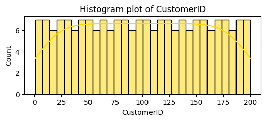

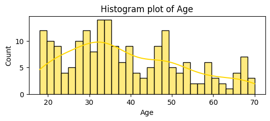

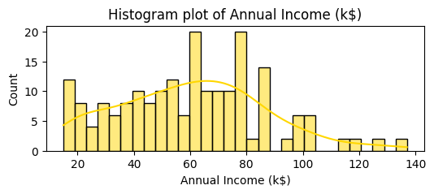

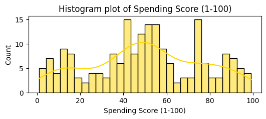

```python
for col in numerical_col:
    plt.figure(figsize=(6,2))
    sns.histplot(x=mall_Customer_data[col],color="gold",kde=True ,bins=30)
    plt.title(f"Histogram plot of {col}")
    plt.show()
```

# Preprocessing :

# 1. Handle null values:

```python
mall_Customer_data.isna().sum()
```

```
CustomerID                0
Gender                    0
Age                       0
Annual Income (k$)        0
Spending Score (1-100)    0
dtype: int64
```

its clearly watching you not missing value in dataset

# 2. Handle category values :

```python
lb = LabelEncoder()
lb
mall_Customer_data.Gender= lb.fit_transform(mall_Customer_data.Gender)
```

```python
mall_Customer_data.Gender[:30]
```

```
0     1
1     1
2     0
3     0
4     0
5     0
6     0
7     0
8     1
9     0
10    1
11    0
12    0
13    0
14    1
```

[output cut: 16 more lines]

# 3. detect Outlines and Remove

```python
for i in mall_Customer_data:
    q1 = mall_Customer_data[i].quantile(0.25)
    q3 = mall_Customer_data[i].quantile(0.75)

    iqr = q3-q1

    lower_bound = q1 - 1.5 * iqr
    upper_bound = q3 + 1.5 * iqr

    mall_Customer_data = mall_Customer_data[(mall_Customer_data[i] >= lower_bound) & ( mall_Customer_data[i] <= upper_bound)]
```

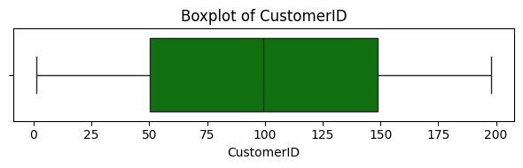

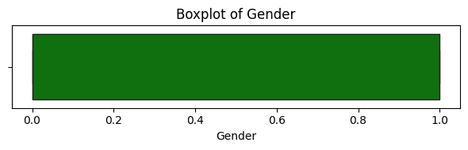

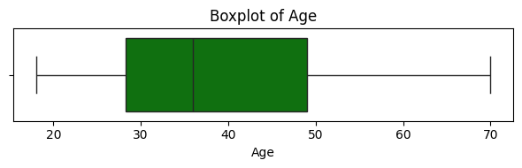

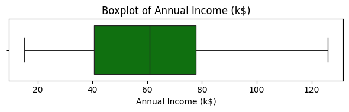

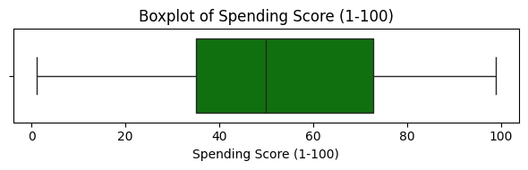

```python
for col in mall_Customer_data:
    plt.figure(figsize=(6, 2))
    sns.boxplot(x=mall_Customer_data[col], color="green")
    plt.title(f"Boxplot of {col}")
    plt.tight_layout()
    plt.show()

import warnings
warnings.simplefilter("ignore")
```

```python
mall_Customer_data.head(5)
```

|  | CustomerID | Gender | Age | Annual Income (k$) | Spending Score (1-100) |
| --- | --- | --- | --- | --- | --- |
| 0 | 1 | 1 | 19 | 15 | 39 |
| 1 | 2 | 1 | 21 | 15 | 81 |
| 2 | 3 | 0 | 20 | 16 | 6 |
| 3 | 4 | 0 | 23 | 16 | 77 |
| 4 | 5 | 0 | 31 | 17 | 40 |

```python
# mall_Customer_data = mall_Customer_data.drop(columns="CustomerID",axis=1, inplace=True)
# print("drop Unnecessary column CustomerID\n",mall_Customer_data)
```

```python
features_col = ["Gender", "Age","Annual Income (k$)","Spending Score (1-100)"]
features_col
```

```
['Gender', 'Age', 'Annual Income (k$)', 'Spending Score (1-100)']
```

```python
x = mall_Customer_data[features_col]
```

# feature scaling

```python
scaler = StandardScaler()
x_scaled = scaler.fit_transform(x)
```

```python
# Optional PCA to 2D Use PCA for to for  2D plot
```

```python
pca = PCA(n_components=2)
x_pca = pca.fit_transform(x_scaled)
```

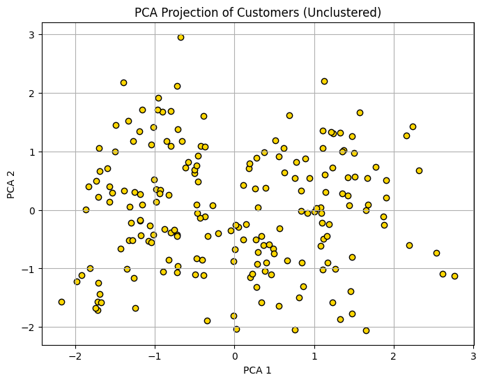

```python
plt.figure(figsize=(8, 6))
plt.scatter(x_pca[:, 0], x_pca[:, 1], c="gold", edgecolor="black")
plt.title("PCA Projection of Customers (Unclustered)")
plt.xlabel("PCA 1")
plt.ylabel("PCA 2")
plt.grid(True)
plt.show()
```

# Step 2: Fit K-Means and Assign Cluster Labels

```python
kmeans = KMeans(n_clusters=5, init="k-means++", random_state=42)
mall_Customer_data["Cluster"] = kmeans.fit_predict(x_scaled)
mall_Customer_data
```

|  | CustomerID | Gender | Age | Annual Income (k$) | Spending Score (1-100) | Cluster |
| --- | --- | --- | --- | --- | --- | --- |
| 0 | 1 | 1 | 19 | 15 | 39 | 2 |
| 1 | 2 | 1 | 21 | 15 | 81 | 2 |
| 2 | 3 | 0 | 20 | 16 | 6 | 2 |
| 3 | 4 | 0 | 23 | 16 | 77 | 2 |
| 4 | 5 | 0 | 31 | 17 | 40 | 2 |
| ... | ... | ... | ... | ... | ... | ... |
| 193 | 194 | 0 | 38 | 113 | 91 | 1 |
| 194 | 195 | 0 | 47 | 120 | 16 | 4 |
| 195 | 196 | 0 | 35 | 120 | 79 | 1 |
| 196 | 197 | 0 | 45 | 126 | 28 | 4 |
| 197 | 198 | 1 | 32 | 126 | 74 | 1 |

198 rows × 6 columns

# Step 3: Elbow Method to Find Optimal K

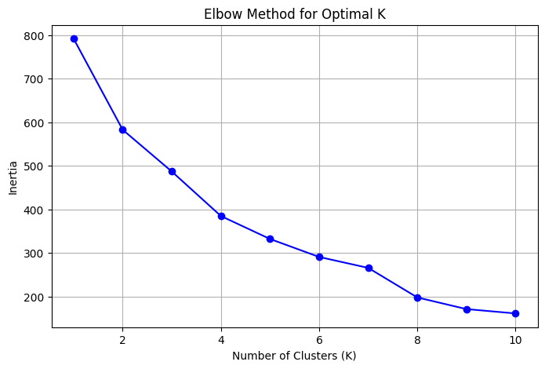

```python
inertias = []
K_range = range(1, 11)

for k in K_range:
    kmeans = KMeans(n_clusters=k, init="k-means++", random_state=42)
    kmeans.fit(x_scaled)
    inertias.append(kmeans.inertia_)

# Plot Elbow Curve
plt.figure(figsize=(8, 5))
plt.plot(K_range, inertias, "bo-")
plt.xlabel("Number of Clusters (K)")
plt.ylabel("Inertia")
plt.title("Elbow Method for Optimal K")
plt.grid(True)
plt.show()
```

# Step 5: Evaluate Clustering Using Silhouette Score

```python
score = silhouette_score(x_scaled, mall_Customer_data["Cluster"])
print(f"Silhouette Score: {score:.2f}")
```

```
Silhouette Score: 0.30
```

This is acceptable, but not very high. Here's how to interpret it:

Silhouette Score Interpretation

> 0.70 Strong structure (very good)

0.50 – 0.70 Reasonable structure (good)

0.30 – 0.50 Weak structure (okay)

< 0.30 No structure (poor)

So, 0.30 is borderline acceptable, meaning:

Clusters are not completely distinct, but there is still some separation.

It may help to experiment with feature selection or try PCA components or try other clustering methods like DBSCAN or Gaussian Mixture for improvement.

# Group by cluster and see average values

```
         CustomerID    Gender        Age  Annual Income (k$)  \
Cluster
0         70.275862  1.000000  56.724138           48.068966
1        161.000000  0.447368  32.763158           85.210526
2         51.788462  0.423077  24.596154           39.211538
3         89.946429  0.000000  47.071429           55.767857
4        165.869565  0.782609  39.260870           88.869565

         Spending Score (1-100)
Cluster
0                     39.724138
1                     82.105263
2                     61.500000
3                     37.517857
4                     16.000000
```

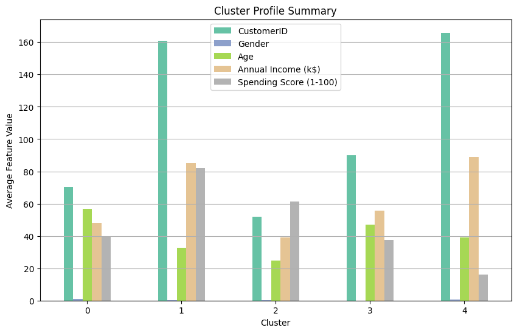

```python
cluster_summary = mall_Customer_data.groupby("Cluster")[feature_cols].mean()
print(cluster_summary)

# Plot cluster-wise feature profiles
cluster_summary.plot(kind="bar", figsize=(10, 6), colormap="Set2")
plt.title("Cluster Profile Summary")
plt.ylabel("Average Feature Value")
plt.xticks(rotation=0)
plt.grid(axis="y")
plt.show()
```